# B5. Control Language

### Loops and Conditionals

#### Loops

Vectorized functions and apply family function are the most efficient methods to execute an operation in bulk in R. However, there are circumstances in which the next execution of an operations depends on the outcome of the previous execution. For example, a Fibonacci sequence is a set of integers in which each integer after the first two is the sum of the previous two digits. *The* Fibonacci sequence typically starts from 0, 1, in which case the sequence would proceed as:

```
Start: 0, 1
0 + 1 = 1
1 + 1 = 2
1 + 2 = 3
2 + 3 = 5
3 + 5 = 8
5 + 8 = 13
```

And so forth. Fibonacci sequences cannot be generated using vectorized operations or apply family functions because the operation of generating the next digit depends on the result from the previous two attempts to generate digits. Loops are the standard computational tool for conducting such operations.

R has three looping functions, `repeat`, `while(){}`, and `for(){}`. It also has tools for deciding what to do during each iteration, including `if(){}` and `else{}`. This example also uses `print()`, which outputs messages to console in a manner that is cleaner than object expression.

```r
> ## make a simple Fibonacci sequence generator
> Fibonacci <- function(x) {
+   y <- sum( x[length(x) - 0:1])
+   return(c(x, y))
+ }
>
> ## repeat will continue to repeat an operations forever, unless you provide a
>   ## break statement. Note the lack of parentheses after repeat.  The looping
>   ## and conditional control words operate differently than the standard R
>   ## function syntax.
> fib_sequence <- 0:1
> repeat {
+   fib_sequence <- Fibonacci(fib_sequence) ## generate the next number
+   if (max(fib_sequence) > 10) break ## end the loop if next number is > 10
+ }
>
> fib_sequence
```

```
[1]  0  1  1  2  3  5  8 13
```

```r
> ## while() incorporates the stopping condition as an argument
> fib_sequence <- 0:1
> while (max(fib_sequence) <= 10) {
+   fib_sequence <- Fibonacci(fib_sequence) ## generate the next number
+ }
>
> fib_sequence
```

```
[1]  0  1  1  2  3  5  8 13
```

```r
> ## for() iterates through a defined set of values which can serve as useful
>   ## indices for bracket operations or do other useful work.
> fib_sequence <- 0:1
>
> for (iteration_value in 1:6) {
+   fib_sequence <- Fibonacci(fib_sequence)
+
+   print(paste( 'iteration_value=', iteration_value ))
+   print(paste( 'New digit=', fib_sequence[iteration_value + 2] ))
+ }
```

```
[1] "iteration_value= 1"
[1] "New digit= 1"
[1] "iteration_value= 2"
[1] "New digit= 2"
[1] "iteration_value= 3"
[1] "New digit= 3"
[1] "iteration_value= 4"
[1] "New digit= 5"
[1] "iteration_value= 5"
[1] "New digit= 8"
[1] "iteration_value= 6"
[1] "New digit= 13"
```

```r
> fib_sequence
```

```
[1]  0  1  1  2  3  5  8 13
```

```r
> ## delete demonstration objects
> remove(fib_sequence, iteration_value, Fibonacci)
```

The key strength of a loop is its ability to make decisions each round. This is computationally expensive because the R interpreter must reengage each round, but can enable your program to do sophisticated decision-making. In the example below, the loop checks the clock once per second and announces the time if the current clock second is divisible by 5. This example also uses `Sys.sleep()`, which is an R function that causes execution of an R script to pause for a specified number of seconds.

```r
> the_time <- Sys.time()
>
> repeat {
+
+   ## force R to wait for one second on each iteration of the loop, so that the
+     ## loop does not iterate too quickly
+   Sys.sleep(1)
+
+   ## record the current time
+   the_time <- c(the_time, Sys.time())
+
+   ## determine if the current clock second is divisible by 5
+   anouncement_decision <- substring(max(the_time), 18, 19)
+   anouncement_decision <- as.numeric(anouncement_decision)
+
+   ## if the current clock second is not divisible by five, print "tick".  If it
+     ## is divisible by 5, print the current time.
+   if (anouncement_decision %% 5 != 0) {
+       print("tick")
+   } else {
+       print(paste("The current time is", Sys.time()))
+           }
+
+   if (max(the_time) - min(the_time) > 9) break ## end loop after 9 seconds
+
+ }
```

```
[1] "The current time is 2020-12-03 11:36:20"
[1] "tick"
[1] "tick"
[1] "tick"
[1] "tick"
[1] "The current time is 2020-12-03 11:36:25"
[1] "tick"
[1] "tick"
[1] "tick"
```

```r
> ## delete demonstration objects
> remove(the_time, anouncement_decision)
```

Loops and apply family functions can do many of the same tasks. However, apply family functions only engage the R interpreter once, which often makes them much more efficient. Strive to only use loops under three conditions:

1. No apply family function can do the task because the outputs from the last round of calculation serve as inputs for the next.
2. While an apply family function can do the task, it would take too much RAM to process all elements at once so the calculation needs to be done one element at a time.
3. You did side-by-side time trials of your loop and an equivalent apply family function and the loop was consistently faster. Starting with R v4.0, this is becoming less rare – v4.0 significantly improved loop efficiency.

To illustrate the nuances of this, here is a side by side performance comparison of `for(){}` and `apply()` on an averaging task. In this example, `for(){}` has approximately 120-140% of the run time of `apply()`. However, if you replace the looped line with the one below it (commented out in the example), the performance difference between the two decreases significantly. In a portion of trials, the loop is actually faster. This change suggests that memory allocation is putting the loop at a disadvantage – each iteration of R is having to reallocate memory for loop_object because the size of one of its elements has changed and this is dragging down the loop’s performance.

```r
> ## CONDUCT A TIME TRIAL ====================
>
> ## Note: typically, one would test each expression multiple times and then
>   ## average the results.  This example does a single trial each to make the
>   ## code easier to follower.
>
> ## make a large data object
> loop_object <- lapply_object <- mapply(
+   FUN= seq,
+   from= 1,
+   to= 2^{1:20},
+   by= pi * 0.1
+   )
> time_trial <- rep(NA, 2)
> names(time_trial) <- c("for", "lapply")
>
> ## use a for(){} loop to calculate means
>
> alternative_loop_result <- rep(NA, length(loop_object))
>
> start_time <- Sys.time()
> for(iter in seq(from= 1, along= loop_object)){
+   loop_object[[iter]] <- mean(loop_object[[iter]]) ## comment line to improve loop performance
+   ## alternative_loop_result[iter] <- mean(loop_object[[iter]]) ## uncomment line to improve loop performance
+   }
> time_trial['for'] <- Sys.time() - start_time
>
> ## use lapply() to do the same
> start_time <- Sys.time()
> lapply_object <- lapply(lapply_object, mean)
> time_trial['lapply'] <- Sys.time() - start_time
>
> ## compare the results (the exact performance will vary from trial to trial
>   ## as well as varying according to your hardware.  For best results, repeat
>   ## your time trial multiple times and then average the results.
> round(time_trial / min(time_trial), 2)
```

```
   for lapply
  1.22   1.00
```

```r
> ## remove demonstration objects
> remove(time_trial, start_time, lapply_object, loop_object, iter,
+   alternative_loop_result)
```

#### Optimization

Optimization problems form an important subset of “last-result-informs-next” loops. In an optimization loop, one tries something, observes the results, and then tries something different to get better results. In R, the `optim()` function does this task. `optim()` has two key arguments. `fn=` is a function for which you want to find the optimal arguments, formulated so that it will return a “score” and lower scores indicate better results. `par=` is an initial set of arguments to supply the function. `optim()` starts with those values and tries variations on them until it finds values that produce the lowest score.

To give an example, imagine that you have a geometric point at coordinate (10, 10) and you want to find another point that is exactly 2 units away. Optimization could be used to find solutions to this problem, as demonstrated below.

```r
> ScoreFunction <- function(x) {
+   y <- x[2]
+   x <- x[1]
+   the_distance <- {x - 10}^2 + {y - 10}^2
+   the_distance <- abs(2 - sqrt(the_distance))
+   return(the_distance)
+ }
>
>
> ## find a solution to this problem, using (0,0) as the initial parameters
> optim(fn= ScoreFunction, par= c(0, 0))
```

```
$par
[1]  8.275144 11.012359

$value
[1] 1.125221e-07

$counts
function gradient
     103       NA

$convergence
[1] 0

$message
NULL
```

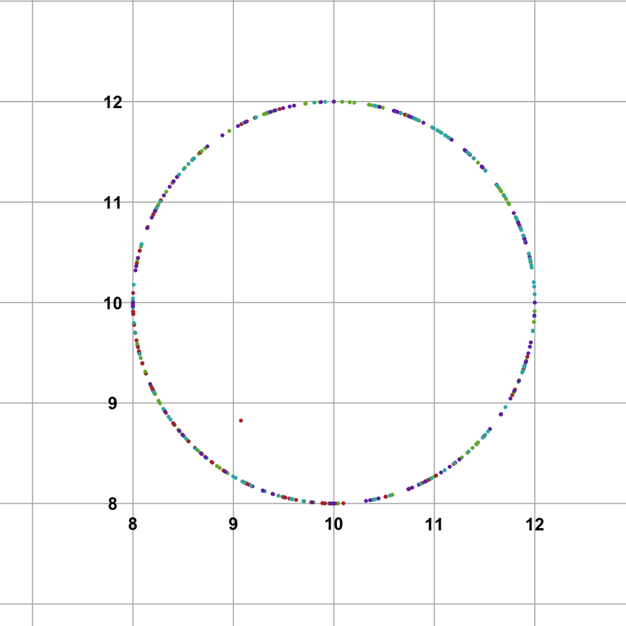

```r
> ## -- plot how the solutions vary, depending on the initial parameters
>
> ## define 441 distinct starting positions
> initial_parameters <- data.frame(
+   row_number= 1:21^2,
+   x_initial= rep(0:20, each= 21),
+   y_initial= rep(0:20, times= 21),
+   x_solution= NA,
+   y_solution= NA
+   )
>
> ## in order to provide further demonstrations of loops in action, use a loop
>   ## to test which solution optim() finds, given different starting positions.
>   ## A lapply() or mapply() would likely be more efficient.
> for(iter in initial_parameters$row_number) {
+
+   initial_parameters[iter, c("x_solution", "y_solution")] <- optim(
+       fn= ScoreFunction,
+       par= initial_parameters[iter, c("x_initial", "y_initial")],
+       control= list(maxit= 10^4)
+           )$par
+
+ }
>
> ## color points according to circle quadrant
> initial_parameters$point_colors <- ifelse(initial_parameters$x_initial > 10, 10,
+   0) + ifelse(initial_parameters$y_initial > 10, 1, 0)
> initial_parameters$point_colors <- as.numeric(as.factor(
+   initial_parameters$point_colors))
> initial_parameters$point_colors <- rainbow(n= 4, s= 0.7, v= 0.7)[
+   initial_parameters$point_colors]
>
> ## plot all solutions found
> plot.new()
> par(xpd= TRUE)
> plot.window(
+   xlim= range(initial_parameters$x_solution),
+   ylim= range(initial_parameters$x_solution),
+   asp= 1
+   )
> abline(h= 0:20, v= 0:20, col= "gray70")
> points(
+   x= initial_parameters$x_solution,
+   y= initial_parameters$y_solution,
+   pch= 16,
+   cex= 0.5,
+   col= initial_parameters$point_colors
+   )
> text(x= 7.8, y= 12:8, labels= 12:8, font= 2)
> text(y= 7.8, x= 12:8, labels= 12:8, font= 2)
```

```r
> ## delete demonstration objects
> remove(initial_parameters, iter, ScoreFunction)
```

In the example above, there are many solutions to this problem, since any point in the ring around (10, 10) qualifies. `optim()` will find one of those solutions, not all. While the same initial parameters will always lead to the same solution, similar initial parameters do not necessarily lead to similar solutions. This is why the point colors on the chart (which roughly categorize the initial parameters into four groups) are randomly distributed around the circle.

#### Conditionals

Loops present many good opportunities to use conditionals like `if(){}` and `else{}` but conditionals can be useful outside of loops as well. For example, conditionals can enable you to toggle into a test mode while you are modifying/debugging code. This example also uses `warning()` wish is the R function for generating warning messages.

```r
> ## FOR THIS EXAMPLE, IMAGINE YOU READ IN A 10m ROW DATASET ====================
>
> ## create dataset with an independent variable
> large_dataset <- data.frame(
+   x= runif(min= 1, max= 100, n= 10^7),
+   y= NA
+   )
>
> ## create a dependent variable with a polynomial relationship to I.V.
> f <- function(x){ {-6 * x^5} + {3 * x^4} + {-5 * x^3} + {3 * x^2} + {-5 * x} }
> large_dataset$y <- f(large_dataset$x)
> remove(f)
>
>
> ## YOU COULD CREATE A TESTING MODE LIKE THIS ====================
>
> ## settings
> my_settings <- list(
+   test_mode= TRUE
+   )
>
> ## if in test mode, take a sample of the dataset
> if (my_settings$test_mode) {
+
+   ## Reduce size of dataset by 80%
+   sample_index <- floor(length(large_dataset$y) * 0.2)
+   set.seed(464)
+   sample_index <- sample(
+       x= seq(along= large_dataset$y),
+       size= sample_index
+       )
+   large_dataset <- large_dataset[sample_index, ]
+
+   ## Throw a warning that script is in test mode
+   warning("Script is currently running in test mode!")
+
+   } else {
+
+       ## print start time for script that may run for a long time
+       print(paste("Script initiated at:", Sys.time()))
+     print("Script is running in standard mode")
+
+   }
```

```
Warning: Script is currently running in test mode!
```

```r
> ## conduct some analysis of dataset
> Sigmoid <- function(x){
+   y <- exp(x) + 1
+   y[y == 0] <- NA
+   y <- exp(x) / y
+   return(y)
+   }
> sigmoid_correlation <- cor( Sigmoid(large_dataset$x), Sigmoid(large_dataset$y) )
>
> print(
+   paste(
+       "The analysis indicates a sigmoid correlation of:",
+       round(sigmoid_correlation, 3)
+       )
+   )
```

```
[1] "The analysis indicates a sigmoid correlation of: -0.291"
```

```r
> ## end code with restatement of test mode warning
> if (my_settings$test_mode) warning("Script is currently running in test mode!")
> ## remove demonstration objects
> remove(sigmoid_correlation, large_dataset, my_settings, Sigmoid)
```

Another common use for conditional expressions is making functions able to adapt to different kinds of inputs. For example, `sample()` is able to receive either a `x=` and `size=` argument or just a `x=` argument. Below is an example function that uses conditional expression to accomplish a similar result. The example uses `&&` and `||`. These operators are forms of the standard logical operators that ignore all but the first element of the logical vector. They are considered “safer” than the standard operators is circumstances where there should only be one element in the logical vectors evaluated. The example also uses `stop()`, which is the function for generating an error message.

```r
> TwoModeSample <- function(x, size= NULL) {
+
+   ## interpret special case #1
+   if (length(x) == 1 && is.null(size) && is.numeric(x)) {
+       if (x < 1)  return(x) else x <- 1:x
+   }
+
+   ## shuffle x (this is one way of taking a sample)
+   sample_index <- runif(n= length(x))
+   sample_index <- order(sample_index)
+   x <- x[sample_index]
+
+   ## interpret special case #2
+   if (is.null(size)) return(x) else {
+
+       ## error check the size input
+       size <- as.integer(size)
+       if (size < 1 || size > length(x)) stop("Invalid \'size\' argument")
+
+       ## return sample
+       return(x[1:size[1]])
+
+       }
+
+ }
>
>
> ## test function with x= and size= arguments
> TwoModeSample(month.abb, 3)
```

```
[1] "Dec" "Jan" "Aug"
```

```r
> ## test function with x= a vector and no size= argument
> TwoModeSample(month.abb)
```

```
 [1] "May" "Jul" "Dec" "Jun" "Apr" "Sep" "Oct" "Nov" "Jan" "Feb" "Mar" "Aug"
```

```r
> ## test function with x= a single integer and no size= argument
> TwoModeSample(5)
```

```
[1] 4 1 2 3 5
```

```r
> TwoModeSample(-5)
```

```
[1] -5
```

```r
> ## test function with an improperly long size argument (the || prevents this
>   ## from causing problems)
> TwoModeSample(month.abb, 3:4)
```

```
[1] "Jun" "Oct" "Jul"
```

```r
> ## these tests should cause errors and do
> # TwoModeSample(month.abb, -3)
> # TwoModeSample(month.abb, 15)
```

In the example above, take note of two things:

1. `return()` is used to end the function and express the result whenever the result has been ascertained for a given test case. When used like this, `return()` causes the function to skip the lines of code that follow it.
2. As with `break` and `repeat` in the loops section, `else` does not have to follow the standard `{}` conventions of R syntax. In general, it is better to brace than to not brace but either is considered acceptable.

### Error Handling

#### Tools for Solving Specific Error Problems

When programming, errors are not the enemy. Error and warning messages let you know that something has gone wrong in the code, providing you with an opportunity to resolve the problem. As a programmer, you should be more worried about things going wrong *without* errors and warnings. Here are some tools to consider as you work to manage errors and warnings.

`stop()` is the R function for generating error messages. Use `stop()` to force your code to abort when something happens that should not happen. One way to do this is to write a `TRUE`/`FALSE` test, pass the test result as an argument to if `if(){}`, and then call `stop()` inside the braces. While `stop()` will abort the execution of a particular function/line of code, some R GUI will continue to run the lines after an aborted line and others will not. `try()` prevents an error from causing a function / line to abort. Instead of generating an error, an errant function encased in `try()`, using the `silent= TRUE` argument, will return a `try-error` class object, as demonstrated below.

```r
> ## express a non-existent object to generate an error
> try_output <- try(object_that_does_not_exist, silent= TRUE)
>
> ## express the try-error object that results
> class(try_output)
```

```
[1] "try-error"
```

```r
> try_output
```

```
[1] "Error in try(object_that_does_not_exist, silent = TRUE) : \n  object 'object_that_does_not_exist' not found\n"
attr(,"class")
[1] "try-error"
attr(,"condition")
<simpleError in doTryCatch(return(expr), name, parentenv, handler): object 'object_that_does_not_exist' not found>
```

```r
> ## build a hook to react to try-error -- creating missing object with
>   ## default values
> if (any(class(try_output) %in% "try-error")) {
+   object_that_does_not_exist <- rep(0, 10)
+ }
>
> ## express newly created object
> object_that_does_not_exist
```

```
 [1] 0 0 0 0 0 0 0 0 0 0
```

```r
> ## delete demonstration objects
> remove(try_output, object_that_does_not_exist)
```

`warning()` is the R function for generating warning messages. You can use it in the same way as `stop()`. However, a warning message will not prevent a function / line of code from executing. `warnings()` will enable you to view all of the warning messages thrown during the execution of a script. `suppressWarnings()` will pass on the expression it encases, while silencing the error messages. Below is an example of `supressWarnings()` in action

```r
> ## generates a warning
> sqrt(-1)
```

```
Warning in sqrt(-1): NaNs produced
```

```
[1] NaN
```

```r
> ## silences the warning
> suppressWarnings(sqrt(-1))
```

```
[1] NaN
```

`unclass()` strips the customized class attributes from an object. This will cause the object to display in a more standard object format. `unclass()` does not change the object itself, just the way R interprets it. In general, you will find that most package-specific R objects are actually just lists with fancy display methods.

```r
> ## this is a t-test object with a t-test class attribute
> t.test(1:10, 11:20)
```

```
    Welch Two Sample t-test

data:  1:10 and 11:20
t = -7.3855, df = 18, p-value = 7.503e-07
alternative hypothesis: true difference in means is not equal to 0
95 percent confidence interval:
 -12.844662  -7.155338
sample estimates:
mean of x mean of y
      5.5      15.5
```

```r
> ## this is a t-test object with the attribute stripped, revealing the basic
>   ## list object structure underneath
> unclass(t.test(1:10, 11:20))
```

```
$statistic
        t
-7.385489

$parameter
df
18

$p.value
[1] 7.503138e-07

$conf.int
[1] -12.844662  -7.155338
attr(,"conf.level")
[1] 0.95

$estimate
mean of x mean of y
      5.5      15.5

$null.value
difference in means
                  0

$stderr
[1] 1.354006

$alternative
[1] "two.sided"

$method
[1] "Welch Two Sample t-test"

$data.name
[1] "1:10 and 11:20"
```

`gc()` triggers RAM clean-up. When you perform operations involving large amounts of data, that data occupies large blocks of RAM. When you delete large data objects from memory, that memory space is eventually returns to the pool of available memory. This process is called garbage collection. Like actual garbage collection, deciding when to do memory garbage collection requires efficiency trade-offs. Do it too often and you waste time and system resources that you could better use elsewhere. Do it too infrequently and the metaphorical garbage piles up, taking up space that could be better used to store useful things. R automatically makes decisions about when to do garbage collection. However, there are circumstances where you can avoid errors if you manually trigger collection. For example, if you load a data object that occupies most of your RAM, your first task will likely to be filter, summarize, or transform that data into the smallest possible format that you will need for your analysis. Your second might be to use `gc()`, triggering garbage collection to free the RAM that the raw data object previously occupied.

The `::` operator enables you to call a function from a package without first loading the package using `library` or in circumstances where the function is masked. This can be particularly useful for working with parallelized operations, where the threads may have difficulty accessing package dependencies. Below is an example of `::` in action, used to resolve issues with function masking.

```r
> ## load the parallel processing package
> library(parallel)
>
> ## use the parallel package's function for detecting the number of cores on your
>   ## machine
> detectCores()
```

```
[1] 16
```

```r
> ## create a new function with the same name (this is a bad practice but can
>   ## happen when you load packages from different creators.  Since the global
>   ## environment has precedence over package environments, this masks the
>   ## version of detectCores() in the parallel package
> detectCores <- function(){"Cores? What cores?"}
> detectCores()
```

```
[1] "Cores? What cores?"
```

```r
> ## using :: you can use it anyway
> parallel::detectCores()
```

```
[1] 16
```

```r
> ## delete demonstration objects and reset the environment
> remove(detectCores)
> detach(package:parallel)
```

#### Tools for Solving Specific Console Output Problems

Keep the amount of expressions (as opposed to assignments) in your code to a minimum. If a line of code does not change any object, it is likely cluttering your script without providing benefit. However, there are circumstances where it is important to enable your script to communicate with you (or anyone else who is running your code). R offers a variety of tools for generating messages or interacting with the expressed messages of other programmers.

`identity()`, `print()`, and `cat()` each enable you to express arguments to console. `print()` and `cat()` express their arguments to the console, regardless of whether they are buried in layers of code like functions and loops. `identity()` expresses its arguments using standard expression. It is equivalent to defining the function `function(x){x}`. In contrast to `cat()` and `print()`, it will only express its argument within the environment (or loop) that contains it.

While `cat()` and `print` are similar, `cat()` works differently than `print()` in at least three ways. First, it will combine multiple expressions into one output. Second, it bypasses object expression and directly prints messages to the console. Third, since it bypasses expression, you cannot assign its output to an object using just the `<-` operator.

Below is a demonstration of the three functions in action.

```r
> ## use print()/cat() to express output directly to console
> identity("I know who I am!")
```

```
[1] "I know who I am!"
```

```r
> print("I am a machine that puts ink on paper!")
```

```
[1] "I am a machine that puts ink on paper!"
```

```r
> cat("I am small, furry carnivore.", "Meow!", "Purrrrrr!")
```

```
I am small, furry carnivore. Meow! Purrrrrr!
```

```r
> ## define a function to test expression option inside a loop inside a function
> DemonstrationFunction <- function(expr, FUN) {
+   for (iter in 1:10) {
+       if (iter == 7) { FUN(expr) }
+       }
+ }
>
> ## test whether each function can express through multiple code layers
> the_expression <- "This is a demonstration"
> DemonstrationFunction(the_expression, identity)
> DemonstrationFunction(the_expression, print)
```

```
[1] "This is a demonstration"
```

```r
> DemonstrationFunction(the_expression, cat)
```

```
This is a demonstration
```

```r
> ## test how each function responds to assignment
> self_identification <- identity("I know who I am!")
> self_identification
```

```
[1] "I know who I am!"
```

```r
> printer <- print("I am a machine that puts ink on paper!")
```

```
[1] "I am a machine that puts ink on paper!"
```

```r
> printer
```

```
[1] "I am a machine that puts ink on paper!"
```

```r
> kitty_cat <- cat("I am small, furry carnivore.", "Meow!", "Purrrrrr!")
```

```
I am small, furry carnivore. Meow! Purrrrrr!
```

```r
> kitty_cat
```

[output not shown]

You may wish to get rid of the communications that have been built into some of the functions you use. Alternately, you may wish to capture the non-expression console outputs for other functions you use. `invisible()` prevents functions from showing up in the terminal. As discussed earlier, `supressWarnings()` performs a similar service for warnings messages. Conversely, `capture.output()` will capture the messages that a function outputs to console, even when the function does not express those messages as assignable output.

```r
> ##  invisible() suppresses console text; leaves assignment operations untouched
> invisible("I am very happy!")
> very_expressive <- invisible("I am very happy!")
> very_expressive
```

```
[1] "I am very happy!"
```

```r
> ## capture.output() diverts console output to the assignment destination object,
>   ## even when assignment would typically come up empty
> kitty_cat <- capture.output(
+   cat("I am small, furry carnivore.", "Meow!", "Purrrrrr!"))
> kitty_cat
```

```
[1] "I am small, furry carnivore. Meow! Purrrrrr!"
```

```r
> ## used in tandem invisible() and capture.output() can completely muzzle print()
> printer <- "I am a machine that puts ink on paper!"
> invisible(print(printer))
```

```
[1] "I am a machine that puts ink on paper!"
```

```r
> capture.output(print(printer))
```

```
[1] "[1] \"I am a machine that puts ink on paper!\""
```

```r
> invisible(capture.output(print(printer)))
>
> ## delete demonstration objects
> remove(DemonstrationFunction, kitty_cat, printer, sample_index,
+   self_identification, the_expression, TwoModeSample, very_expressive)
```

### Analyzing Objects and Functions

#### Analyzing Objects

Lists are the favored object structure for the specialized objects underlying most packages because a list can hold an arbitrary number of objects within it. If you `unclass()` most specialty objects in R, you will find a list underneath. However, since lists nest inside other lists, complex list objects can be difficult to understand at a glance. While it takes some practice before `str()` outputs become intuitive, this function can be powerful tool for making sense of complex lists.

```r
> ## generate a list with complex sub-lists
> x <- 1:10
> y <- x^2
> complex_list <- list(
+   "A"= list(
+       "String"= paste(letters, LETTERS),
+       "Integers"= 100:110
+     ),
+   "B"= list(
+       "T Test List"= unclass(t.test(x, y)),
+       "Factors"= as.factor(month.abb)
+           )
+ )
>
> ## use str() to analyse the object, starting with the top level
> str(complex_list, max.level= 1)
```

```
List of 2
 $ A:List of 2
 $ B:List of 2
```

```r
> ## adjust max.level to dive deeper into the list - 2 levels
> str(complex_list, max.level= 2)
```

```
List of 2
 $ A:List of 2
  ..$ String  : chr [1:26] "a A" "b B" "c C" "d D" ...
  ..$ Integers: int [1:11] 100 101 102 103 104 105 106 107 108 109 ...
 $ B:List of 2
  ..$ T Test List:List of 10
  ..$ Factors    : Factor w/ 12 levels "Apr","Aug","Dec",..: 5 4 8 1 9 7 6 2 12 11 ...
```

```r
> ## adjust max.level to dive deeper into the list - 3 levels
> str(complex_list, max.level= 3)
```

```
List of 2
 $ A:List of 2
  ..$ String  : chr [1:26] "a A" "b B" "c C" "d D" ...
  ..$ Integers: int [1:11] 100 101 102 103 104 105 106 107 108 109 ...
 $ B:List of 2
  ..$ T Test List:List of 10
  .. ..$ statistic  : Named num -3.04
  .. .. ..- attr(*, "names")= chr "t"
  .. ..$ parameter  : Named num 9.14
  .. .. ..- attr(*, "names")= chr "df"
  .. ..$ p.value    : num 0.0137
  .. ..$ conf.int   : num [1:2] -57.48 -8.52
  .. .. ..- attr(*, "conf.level")= num 0.95
  .. ..$ estimate   : Named num [1:2] 5.5 38.5
  .. .. ..- attr(*, "names")= chr [1:2] "mean of x" "mean of y"
  .. ..$ null.value : Named num 0
  .. .. ..- attr(*, "names")= chr "difference in means"
  .. ..$ stderr     : num 10.8
  .. ..$ alternative: chr "two.sided"
  .. ..$ method     : chr "Welch Two Sample t-test"
  .. ..$ data.name  : chr "x and y"
  ..$ Factors    : Factor w/ 12 levels "Apr","Aug","Dec",..: 5 4 8 1 9 7 6 2 12 11 ...
```

```r
> ## remove demonstration objects
> remove(complex_list, x, y)
```

Meta-data is information about a body of data. In R, there are multiple options for attaching meta-data to an object. We have already encountered meta-data in the form of `names()`, `dimnames()`, and `class()`. Each of these are “attributes” of objects. The `attributes()` function will express all of the attributes currently attached to an object. `attr()` can retrieve a specific attribute by name or enable you to add or edit attributes.

```r
> ## make a dataset
> a_dataset <- data.frame(
+   x= round(seq(from= 1/24, to= 23/24, length.out= 12) * 100),
+   y= month.name,
+   z= as.logical({1:12} %% 2)
+   )
> head(a_dataset)
```

```
   x        y     z
1  4  January  TRUE
2 12 February FALSE
3 21    March  TRUE
4 29    April FALSE
5 38      May  TRUE
6 46     June FALSE
```

```r
> ## explore its existing attributes
> attributes(a_dataset)
```

```
$names
[1] "x" "y" "z"

$class
[1] "data.frame"

$row.names
 [1]  1  2  3  4  5  6  7  8  9 10 11 12
```

```r
> attr(a_dataset, "row.names")
```

```
 [1]  1  2  3  4  5  6  7  8  9 10 11 12
```

```r
> rownames(a_dataset) # this function does the same attribute pull
```

```
 [1] "1"  "2"  "3"  "4"  "5"  "6"  "7"  "8"  "9"  "10" "11" "12"
```

```r
> attr(a_dataset, "class")
```

```
[1] "data.frame"
```

```r
> class(a_dataset) # this function does the same attribute pull
```

```
[1] "data.frame"
```

```r
> ## change the row.names attribute to month.abb
> head(a_dataset)
```

```
   x        y     z
1  4  January  TRUE
2 12 February FALSE
3 21    March  TRUE
4 29    April FALSE
5 38      May  TRUE
6 46     June FALSE
```

```r
> attr(a_dataset, "row.names") <- month.abb
> head(a_dataset)
```

```
     x        y     z
Jan  4  January  TRUE
Feb 12 February FALSE
Mar 21    March  TRUE
Apr 29    April FALSE
May 38      May  TRUE
Jun 46     June FALSE
```

```r
> ## add a new attribute
> attr(a_dataset, "short.months") <- "Feb"
> attributes(a_dataset)
```

```
$names
[1] "x" "y" "z"

$class
[1] "data.frame"

$row.names
 [1] "Jan" "Feb" "Mar" "Apr" "May" "Jun" "Jul" "Aug" "Sep" "Oct" "Nov" "Dec"

$short.months
[1] "Feb"
```

```r
> ## delete demonstration object
> remove(a_dataset)
```